# Estadísticas de Facebook

Benjamín Urrutia

30-10-2020

# Introducción

Hoy en día las redes sociales son cada vez más comunes entre las personas, llegando al punto en el que es muy difícil conocer a alguien que no utilice Twitter, Instagram o **Facebook**.

Esta última mencionada es una de las más conocidas. Se estima que hay alrededor de unos **2.400 millones de usuarios activos**. A nivel mundial, sabemos que millones de personas publican distintos tipos de post y cada uno con distintos objetivos, como por ejemplo, vender un producto, informar sobre algún tema, etc.

Muchos usuarios buscan crecer en la red social. Para lograr esto, **es de suma importancia saber cómo se comporta tu post**. Es por esto que Facebook implementó estadísticas de cada post que uno realiza. Independiente de cual sea el objetivo del post, uno puede tener información sobre el alcance de tu post, número de likes, interacciones, entre otras cosas. No obstante, muchos usuarios no saben como utilizar esta herramienta para sacarle un mejor provecho a sus páginas.

Es por esto que en este informe se busca **examinar que impacto tiene, en Facebook, cada tipo de post**. Vamos a analizar el alcance, el número de interacciones, likes, comentarios, entre otras cosas. Para ello, estudiaremos por separado cada tipo de publicación: videos, fotos, estados y link.

En este trabajo vamos a **analizar detalladamente las variables más influyentes** de la base de datos `Facebook metrics Data Set`. Cada variable va a tener una breve explicación de lo que representa. Luego vamos a ver, a través de gráficos y medidas de resúmen, cómo se comporta cada tipo de post para concluir qué nos conviene compartir, videos, fotos, estados o link, para tener un mayor impacto en esta red social.

# Desarrollo

## Distintos tipos de post

Para partir nuestro analisis veamos que tipo de post hay y que tantas publicaciones tienen cada uno de estos.

Entendamos como `Link` como un enlace que lleva a otra página web ,`Photo` un post que contiene una imagen y`Status` una publicación que contiene solo texto (`Video` es autoexplicativo)

Veamos gráficamente que sucede

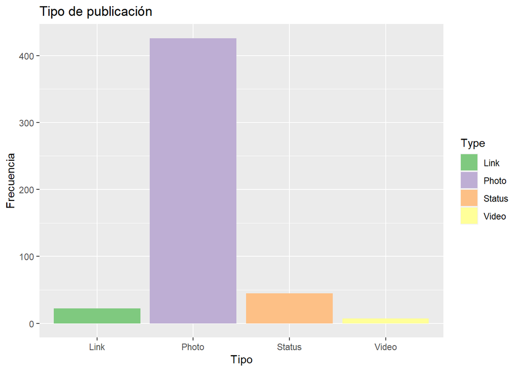

Como podemos ver en el gráfico, el número de publicaciones de fotos (color morado) es mucho más alto en comparación al resto de post.

Es por esto que analizar, por ejemplo, el total de likes de cada publicación no tiene mucho sentido ya que, al haber más fotos, el total de likes va a ser mayor que el resto. No obstante, esto no significa que una foto tenga más likes que un video.

Por esta razón, nuestro análisis se va a enfocar en cada tipo de post y como se comporta este.

| Tipo de Post | Cantidad de publicaciones | Porcentaje del Total |
| --- | --- | --- |
| Link | 22 | 4.4% |
| Foto | 426 | 85.2% |
| Video | 7 | 1.4% |
| Estado | 45 | 9% |

## Categoría de la publicación

Esta variable cuenta con tres tipos de categorias: **Action**, **Product** y **Inspiration**. La categoria *action* se refiere a **ofertas especiales y concursos**, *Product* hace referencia a **publicidad directa con contenido de marca explícito** y, por último, *Insiration* esta relacionado con post **sin contenido de marca explícito**.

Veamos gráficamente como se comportan

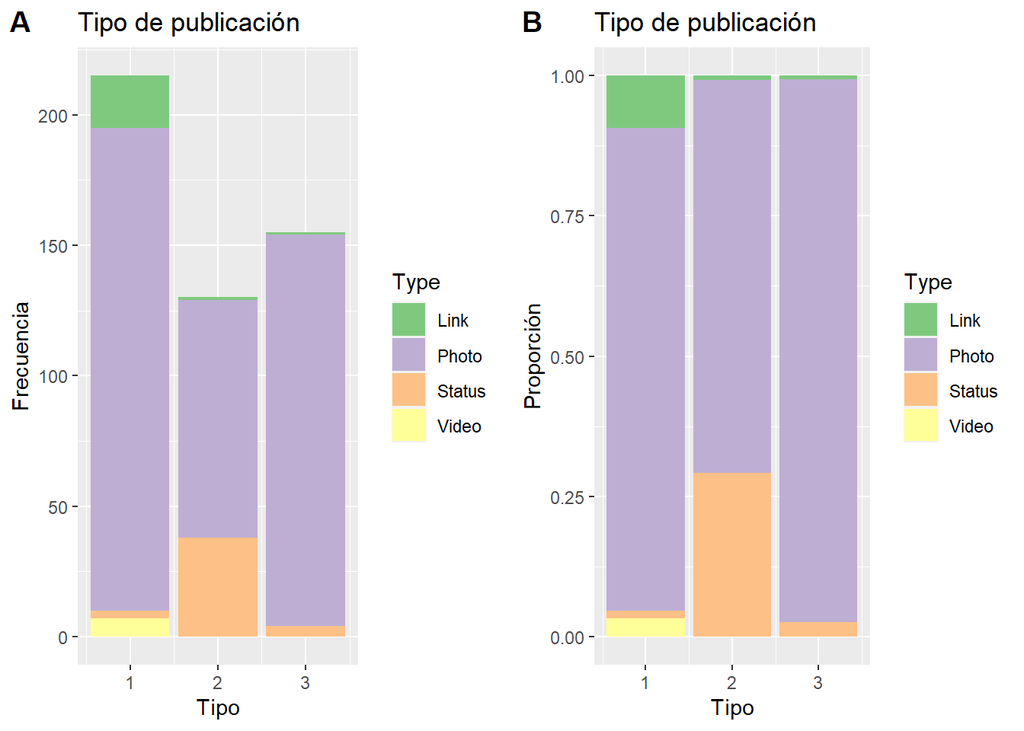

Como podemos ver en el primer gráfico, hay una mayor cantidad de post dentro de la categoria *Action*, seguido de *Inspiration* y, por último, *Product*.

En el segundo, vemos de manera gráfica la proporción de cada post dentro de cada categoría.

Veamos numericamente como se comporta cada tipo publicación

[output not shown]

Como mencionamos antes, generalmente, los links y videos son para concursos y ofertas especiales mientras que los estados se relacionan en su mayoría con publicidad directa. En las fotos pasa algo similiar, hay una gran cantidad dentro de la categoria Action, seguido de Inspiration y, por último, Product.

Teniendo en cuenta como se suelen utlizan los tipos de post, veamos los impactos que estos tienen dentro de Facebook.

## Alcance Total

La variable `Alcance Total` se refiere a la cantidad de usuarios únicos que vieron tu post, es decir, si un mismo usuario ve tu publicación dos veces solo se contabiliza una.

Para analizar como se comportan los post, vamos a ver un gráfico Boxplot. Para aprender a interpretarlo podemos ver el siguiente [link](https://www.pgconocimiento.com/diagrama-boxplot/#:~:text=Asimetr%C3%ADa%20positiva%20o%20segada%20a,la%20inferior%20a%20la%20mediana.).

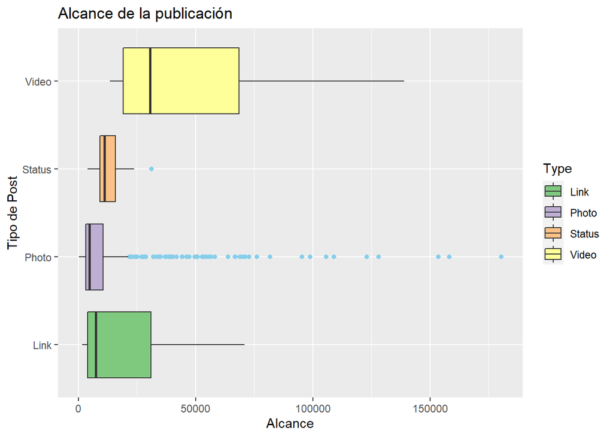

Como podemos ver la categoría `Video` es la que mayor mediana tiene. No obstante hay que tener en cuenta que hay solo 7 datos de este post en nuestra base de datos.

Sobre la categoría `Status` o Estado, vemos que tiene una menor mediana en comparación a los videos pero levemente mayor a la de los otros tipos de post. Además presenta un valor extremo por la parte superior.

Sobre la categoria `link` vemos que, a pesar de tener una mediana menor que los estados, vemos que tiene un alcance máximo más alto que el de los estados.

Por último, sobre la variable `Photo` o Foto, si bien es la que menor mediana tiene, es la que más datos presenta. Además, podemos ver que tiene muchos valores extremos o outliers. Podemos ver que la mediana está cercana al límite inferior del cajón, lo que quiere decir que la mitad de los datos se encuentran bajo ese valor, con un alcance bastante pequeño, mientras que la otra mitad se encuentra sobre ese valor, con un alcance bastante mayor.

Ahora veamos númericamente.

| Tipo de Post | Mediana | Media | Desviación Estándar | Mínimo | Máximo |
| --- | --- | --- | --- | --- | --- |
| Link | 7422 | 18545 | 21399 | 1536 | 70912 |
| Foto | 4675 | 13138 | 22878 | 238 | 180480 |
| Video | 30624 | 51206 | 48825 | 13544 | 139008 |
| Estado | 11096 | 13079 | 5218 | 3930 | 31136 |

Podemos ver en la tabla anterior que los Videos tienen mayor mediana y media que los demás tipos de post. No obstante, al ser pocos datos, tambien tienen una gran dispersión.

Además, vemos que el máximo alcance de las Fotos es mayor que el de cualquier otro tipo de post. No obstante, tiene una mediana bastante pequeña, siendo la menor de las categorías y, además, vemos que la media tambien es de las más bajas junto con los Estados.

Por lo que, en general, los Videos suelen tener un mayor alcance que los demás post. Sin embargo, hay que tener en cuenta que hay pocos datos en esta categoria. Cabe destacar que los Estados tienen una media y mediana bastante parecida, por lo que su dispersión es poca, teniendo una desviación bastante pequeña.

## Impresiones Totales

Esta variable se refiere a la cantidad de veces que se ve tu post. A diferencia de la variable anterior, en este caso, si un usuario ve más de una vez tu post, se contabilizan todas las veces que las haya visto, es decir, un único usuario puede generar más de una impresión.

Veamos gráficamente como se comporta.

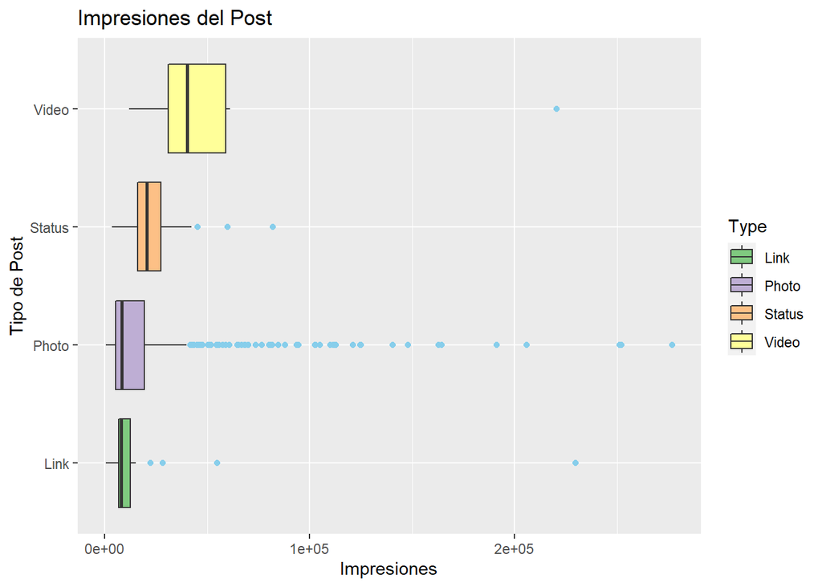